# explore_species

Aurore A. Maureaud

2022

Exploring the flags and processing methods on several crab species, here:

```
## [1] "Cancer borealis"
```

## 1. No filter

Occurrence points based on the raw occurrence data from OBIS and GBIF, with no filtering, but after the OBIS-GBIF deduplication methods applied.

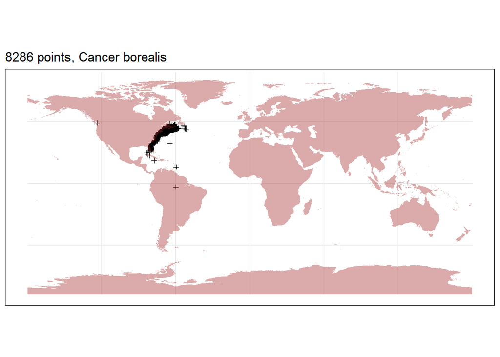

## 2. Occurrence filters

Occurrence spatial points are filtered based on flags of sveeral categories:

- missing year
- problem with coordinate (0 island or missing)
- removing the points with high coordinates uncertainty
- remove on land points

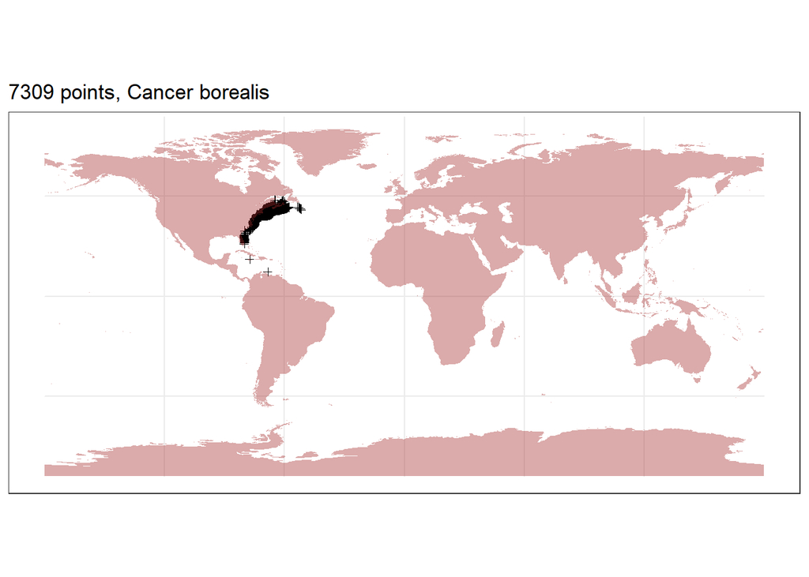

## 3. Habitat information and BPOW

The depth range expected of the species is used to check the bathymetric groups in which the species is found:

- we used the depth range of the species from SeaLifeBase species profiles
- we translated that depth range into broad bathymetric categories used in the BPOW biogeographic regionalization layer:
1. 0-800m: coastal and upper bathyal
2. 800-3,500m: bathyal
3. 3,500-6,500m: abyssal
4. 6,500m: hadal trenches
- we compared to the two

```
## [1] "depth range: 0-800"
```

```
## [1] "bathymetric groups: coastal" "bathymetric groups: bathyal"
```

```
## although coordinates are longitude/latitude, st_intersects assumes that they are planar
## although coordinates are longitude/latitude, st_intersects assumes that they are planar
```

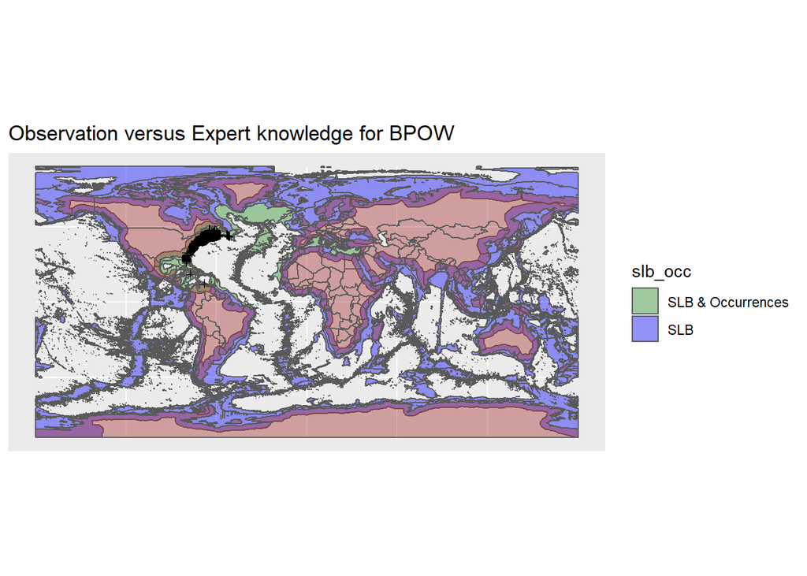

## 4. FAO zone presence

The fishing FAO areas are used to incidate the expected presence of the species in several sub-ocean areas:

- the reference used is the list of FAO areas from SeaLifeBase species profiles
- the FAO shapefile is used to indicate the FAO areas in which the species is found based on the occurrence spatial points
- the two are compared

```
## although coordinates are longitude/latitude, st_intersects assumes that they are planar
## although coordinates are longitude/latitude, st_intersects assumes that they are planar
```

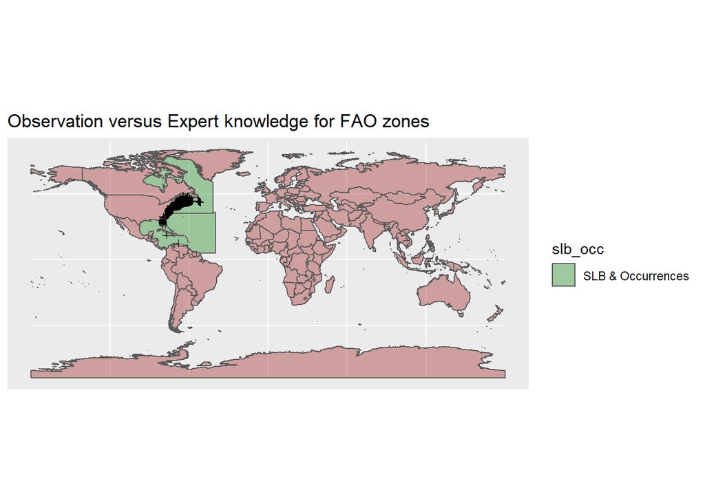